# Descripcion Base de Datos

Esta base de datos describe las entregas de pedidos, incluyendo información sobre agentes de entrega, condiciones climáticas, tiempos de entrega, y detalles geográficos de las rutas. A continuación, se presenta un análisis de la composición de la base de datos:

**Estructura de los datos**:

- Los datos son **estructurados**, ya que están organizados en un formato tabular con filas y columnas claramente definidas.

**Formato del archivo**:

- Los datos se encuentran en formato **CSV** (valores separados por comas), lo cual facilita su manipulación mediante herramientas de análisis de datos como Python (con librerías como Pandas).

**Parser**:

- No es necesario el empleo de un parser especializado para extraer la información, ya que el formato CSV es legible por múltiples herramientas de análisis de datos. Se puede cargar directamente usando funciones como `pd.read_csv()` en Python.

**Tipología de las variables**:

- **Cualitativas**:
  - **Nominales**: Variables como el tipo de clima (`Weather`), el vehículo (`Vehicle`), y la categoría del pedido (`Category`) son de tipo nominal, ya que no presentan un orden inherente entre los valores.
- **Cuantitativas**:
  - **Discretas**: Variables como la edad del agente (`Agent_Age`), las coordenadas geográficas (`Store_Latitude`, `Store_Longitude`, etc.), y el número de minutos en tiempos de entrega (`Delivery_Time`) son discretas porque toman valores específicos.
  - **Continuas**: Algunas de las variables geográficas como las latitudes y longitudes podrían considerarse continuas, ya que pueden tomar cualquier valor dentro de un rango.

Esta base de datos proporciona un marco estructurado para analizar fenómenos relacionados con la logística y el rendimiento de los agentes de entrega.

## Librerias

```python
import numpy as np
import pandas as pd
import matplotlib.pyplot as plt
import seaborn as sns
from sklearn.model_selection import train_test_split,GridSearchCV
from sklearn.preprocessing import StandardScaler, OneHotEncoder
from sklearn.svm import SVC
from sklearn.metrics import accuracy_score, classification_report, roc_auc_score, confusion_matrix
from sklearn.pipeline import make_pipeline
from sklearn.svm import SVC
from sklearn.model_selection import train_test_split
from sklearn.preprocessing import StandardScaler
import tensorflow as tf
from tensorflow.keras.models import Sequential
from tensorflow.keras.layers import Dense
import optuna
from tensorflow.keras.optimizers import Adam
from scipy.stats import spearmanr
```

## Leer Datos

```python
data = pd.read_csv('C:\\Users\\santi\\OneDrive\\Escritorio\\Data analitics\\introduccion a ciencia de datos\\amazon delivery\\amazon_delivery.csv')
data
```

|  | Order_ID | Agent_Age | Agent_Rating | Store_Latitude | Store_Longitude | Drop_Latitude | Drop_Longitude | Order_Date | Order_Time | Pickup_Time | Weather | Traffic | Vehicle | Area | Delivery_Time | Category |
| --- | --- | --- | --- | --- | --- | --- | --- | --- | --- | --- | --- | --- | --- | --- | --- | --- |
| 0 | ialx566343618 | 37 | 4.9 | 22.745049 | 75.892471 | 22.765049 | 75.912471 | 3/19/2022 | 11:30:00 | 11:45:00 | Sunny | High | motorcycle | Urban | 120 | Clothing |
| 1 | akqg208421122 | 34 | 4.5 | 12.913041 | 77.683237 | 13.043041 | 77.813237 | 3/25/2022 | 19:45:00 | 19:50:00 | Stormy | Jam | scooter | Metropolitian | 165 | Electronics |
| 2 | njpu434582536 | 23 | 4.4 | 12.914264 | 77.678400 | 12.924264 | 77.688400 | 3/19/2022 | 8:30:00 | 8:45:00 | Sandstorms | Low | motorcycle | Urban | 130 | Sports |
| 3 | rjto796129700 | 38 | 4.7 | 11.003669 | 76.976494 | 11.053669 | 77.026494 | 4/5/2022 | 18:00:00 | 18:10:00 | Sunny | Medium | motorcycle | Metropolitian | 105 | Cosmetics |
| 4 | zguw716275638 | 32 | 4.6 | 12.972793 | 80.249982 | 13.012793 | 80.289982 | 3/26/2022 | 13:30:00 | 13:45:00 | Cloudy | High | scooter | Metropolitian | 150 | Toys |
| ... | ... | ... | ... | ... | ... | ... | ... | ... | ... | ... | ... | ... | ... | ... | ... | ... |
| 43734 | jlxf819993117 | 30 | 4.8 | 26.902328 | 75.794257 | 26.912328 | 75.804257 | 3/24/2022 | 11:35:00 | 11:45:00 | Windy | High | motorcycle | Metropolitian | 160 | Home |
| 43735 | aevx342135787 | 21 | 4.6 | 0.000000 | 0.000000 | 0.070000 | 0.070000 | 2/16/2022 | 19:55:00 | 20:10:00 | Windy | Jam | motorcycle | Metropolitian | 180 | Jewelry |
| 43736 | xnek760674819 | 30 | 4.9 | 13.022394 | 80.242439 | 13.052394 | 80.272439 | 3/11/2022 | 23:50:00 | 0:05:00 | Cloudy | Low | scooter | Metropolitian | 80 | Home |
| 43737 | cynl434665991 | 20 | 4.7 | 11.001753 | 76.986241 | 11.041753 | 77.026241 | 3/7/2022 | 13:35:00 | 13:40:00 | Cloudy | High | motorcycle | Metropolitian | 130 | Kitchen |
| 43738 | nsyz997960170 | 23 | 4.9 | 23.351058 | 85.325731 | 23.431058 | 85.405731 | 3/2/2022 | 17:10:00 | 17:15:00 | Fog | Medium | scooter | Metropolitian | 180 | Cosmetics |

43739 rows × 16 columns

```python
data.info()
```

```
<class 'pandas.core.frame.DataFrame'>
RangeIndex: 43739 entries, 0 to 43738
Data columns (total 16 columns):
 #   Column           Non-Null Count  Dtype
---  ------           --------------  -----
 0   Order_ID         43739 non-null  object
 1   Agent_Age        43739 non-null  int64
 2   Agent_Rating     43685 non-null  float64
 3   Store_Latitude   43739 non-null  float64
 4   Store_Longitude  43739 non-null  float64
 5   Drop_Latitude    43739 non-null  float64
 6   Drop_Longitude   43739 non-null  float64
 7   Order_Date       43739 non-null  object
 8   Order_Time       43739 non-null  object
 9   Pickup_Time      43739 non-null  object
 10  Weather          43648 non-null  object
 11  Traffic          43739 non-null  object
 12  Vehicle          43739 non-null  object
 13  Area             43739 non-null  object
 14  Delivery_Time    43739 non-null  int64
 15  Category         43739 non-null  object
dtypes: float64(5), int64(2), object(9)
memory usage: 5.3+ MB
```

# EDA

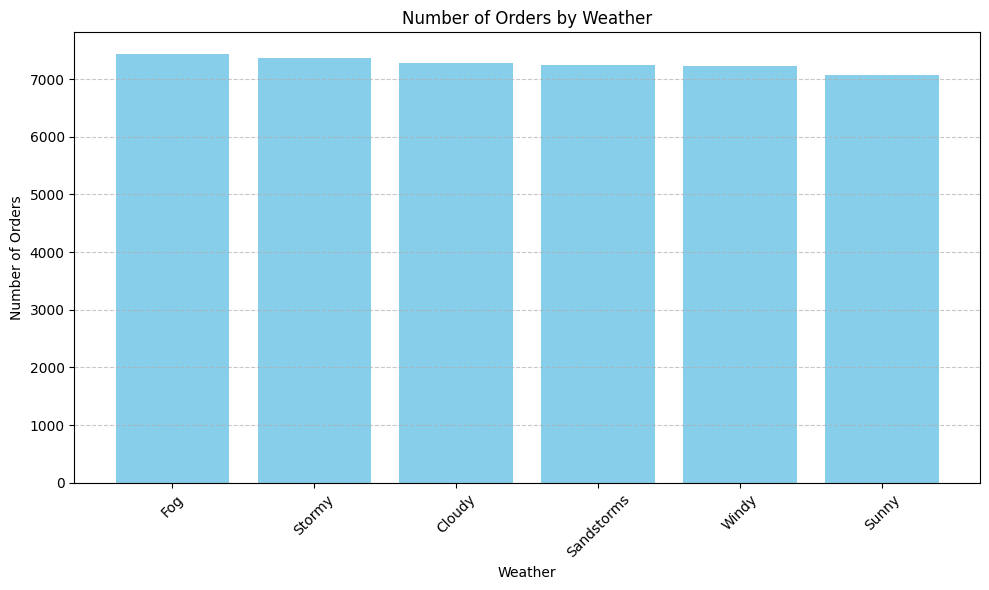

```python
df = pd.DataFrame(data)

# Count the number of orders by weather
weather_counts = df['Weather'].value_counts()

# Create the plot
plt.figure(figsize=(10, 6))
plt.bar(weather_counts.index, weather_counts.values, color='skyblue')
plt.xlabel('Weather')
plt.ylabel('Number of Orders')
plt.title('Number of Orders by Weather')
plt.xticks(rotation=45)
plt.grid(axis='y', linestyle='--', alpha=0.7)

# Show the plot
plt.tight_layout()
plt.show()
```

### categorias

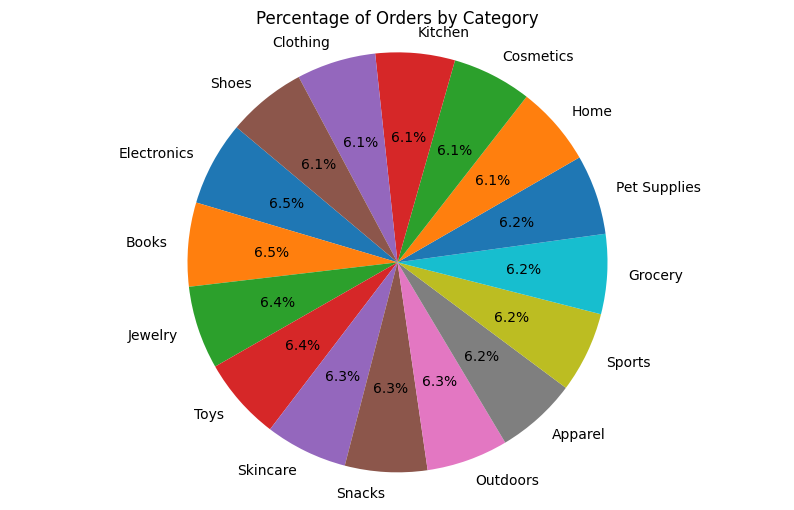

```python
# Calculate the percentage of each category
category_counts = df['Category'].value_counts()
category_percentages = category_counts / category_counts.sum() * 100

# Plot
plt.figure(figsize=(10, 6))
plt.pie(category_percentages, labels=category_percentages.index, autopct='%1.1f%%', startangle=140)
plt.title('Percentage of Orders by Category')
plt.axis('equal')  # Equal aspect ratio ensures that pie is drawn as a circle.
plt.show()
```

### histograma de tiempos de entrega

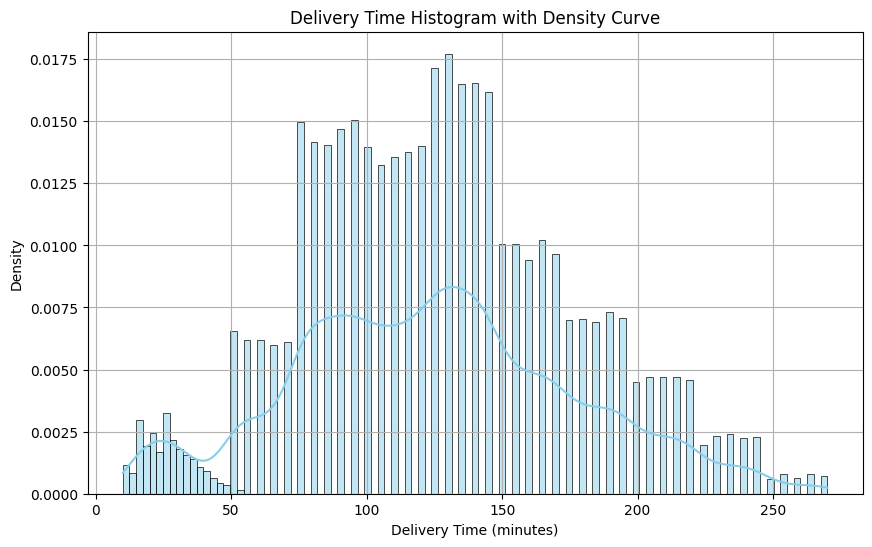

```python
# Create histogram with density curve
plt.figure(figsize=(10, 6))
sns.histplot(df['Delivery_Time'], kde=True, bins=105, color='skyblue', edgecolor='black', stat='density')

# Configure titles and labels
plt.title('Delivery Time Histogram with Density Curve')
plt.xlabel('Delivery Time (minutes)')
plt.ylabel('Density')

plt.grid(True)
plt.show()
```

## Entregas por Vehiculo

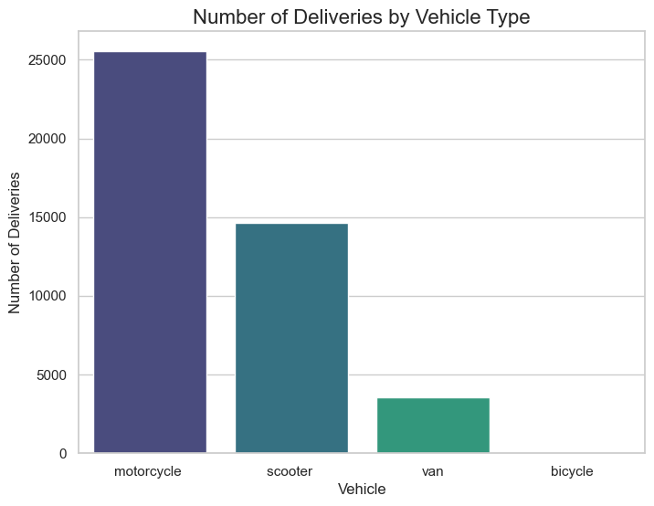

```python
vehicle_counts = df['Vehicle'].value_counts()

# Set up the plot style
sns.set(style="whitegrid")

# Create the bar plot
plt.figure(figsize=(8, 6))
sns.barplot(x=vehicle_counts.index, y=vehicle_counts.values, palette="viridis")

# Add titles and labels
plt.title('Number of Deliveries by Vehicle Type', fontsize=16)
plt.xlabel('Vehicle', fontsize=12)
plt.ylabel('Number of Deliveries', fontsize=12)

# Show the plot
plt.show()
```

la entregas en bicileta son muy pocas 15 , por la cantidad de datos no se hace visible en las graficas

### Clasificación de Categorías Según Tiempo de Entrega Promedio

```python
# Calculate the average delivery times by category
avg_delivery_times = df.groupby('Category')['Delivery_Time'].mean()

# Define the limits for each range
low_limit = 120
high_limit = 150

# Classify the categories
def classify_time(delivery_time):
    if delivery_time <= low_limit:
        return 'Low'
    elif low_limit < delivery_time <= high_limit:
        return 'Medium'
    else:
        return 'High'

# Apply the classification
classified_categories = avg_delivery_times.apply(classify_time)

# Create a DataFrame to show the results
result_df = pd.DataFrame({
    'Average Delivery Times': avg_delivery_times,
    'Range': classified_categories
}).sort_values(by='Average Delivery Times', ascending=False)

# Display the results
print(result_df)
```

```
              Average Delivery Times   Range
Category
Cosmetics                 132.902503  Medium
Kitchen                   132.326973  Medium
Sports                    132.247150  Medium
Apparel                   132.048789  Medium
Skincare                  132.027417  Medium
Snacks                    131.904332  Medium
Pet Supplies              131.291822  Medium
Shoes                     131.151538  Medium
Outdoors                  131.059337  Medium
Books                     131.021601  Medium
Home                      130.955307  Medium
Electronics               130.837136  Medium
Jewelry                   130.753034  Medium
Clothing                  130.483690  Medium
Toys                      129.395901  Medium
Grocery                    26.539576     Low
```

## Cálculo de Distancia entre Dos Ubicaciones

La distancia entre el punto de origen (latitud y longitud de la tienda) y el punto de entrega (latitud y longitud de la entrega) se calcula utilizando la fórmula de la distancia Euclidiana:

$$ d = \sqrt{(\text{Drop\_Latitude} - \text{Store\_Latitude})^2 + (\text{Drop\_Longitude} - \text{Store\_Longitude})^2} $$

donde: \begin{align*} \text{Drop\_Latitude} & : \text{Latitud del punto de entrega} \\ \text{Store\_Latitude} & : \text{Latitud de la tienda} \\ \text{Drop\_Longitude} & : \text{Longitud del punto de entrega} \\ \text{Store\_Longitude} & : \text{Longitud de la tienda} \end{align*}

```python
def euclidean_distance(lat1, lon1, lat2, lon2):
    # Convertir de grados a kilómetros (usando la aproximación de 111.32 km por grado)
    return np.sqrt((lat2 - lat1)**2 + (lon2 - lon1)**2) * 111.32  # 111.32 km por grado

# Aplicar la función
df['Distance_km'] = df.apply(lambda row: euclidean_distance(row['Store_Latitude'], row['Store_Longitude'],
                                                             row['Drop_Latitude'], row['Drop_Longitude']), axis=1)

# Mostrar resultados
print(df[['Order_ID', 'Distance_km']])
```

```
            Order_ID  Distance_km
0      ialx566343618     3.148605
1      akqg208421122    20.465933
2      njpu434582536     1.574303
3      rjto796129700     7.871513
4      zguw716275638     6.297210
...              ...          ...
43734  jlxf819993117     1.574303
43735  aevx342135787    11.020118
43736  xnek760674819     4.722908
43737  cynl434665991     6.297210
43738  nsyz997960170    12.594420

[43739 rows x 2 columns]
```

### Distancia Promedio y Maxima Distancia

```python
# Calculate the average delivery distance
average_distance = df['Distance_km'].mean()
max_distance = df['Distance_km'].max()

print(f'Average Delivery Distance: {average_distance:.2f} km')
print(f'Maximum Delivery Distance: {max_distance:.2f} km')

# Obtener el valor máximo de la columna 'Distance'
max_distance = df['Distance_km'].max()

# Encontrar la fila que contiene ese valor máximo
max_distance_row = df[df['Distance_km'] == max_distance]

# Imprimir la fila
print(max_distance_row)
```

```
Average Delivery Distance: 39.11 km
Maximum Delivery Distance: 20321.04 km
            Order_ID  Agent_Age  Agent_Rating  Store_Latitude  \
32179  qkrp333211010         50           6.0      -22.533662

       Store_Longitude  Drop_Latitude  Drop_Longitude Order_Date Order_Time  \
32179       -88.366217      22.663662       88.496217  2/18/2022       NaN

      Pickup_Time Weather Traffic   Vehicle            Area  Delivery_Time  \
32179    21:50:00     NaN    NaN   scooter   Metropolitian             140

      Category   Distance_km
32179  Apparel  20321.044058
```

```python
# Convertir los valores negativos de 'Store_Latitude' a positivos
df['Store_Latitude'] = df['Store_Latitude'].abs()
df['Store_Longitude'] = df['Store_Longitude'].abs()

# Verifica los resultados
print(df[['Order_ID', 'Store_Latitude','Store_Longitude']].head())
```

```
        Order_ID  Store_Latitude  Store_Longitude
0  ialx566343618       22.745049        75.892471
1  akqg208421122       12.913041        77.683237
2  njpu434582536       12.914264        77.678400
3  rjto796129700       11.003669        76.976494
4  zguw716275638       12.972793        80.249982
```

se vuelve a calcular las distancias

```python
def euclidean_distance(lat1, lon1, lat2, lon2):
    # Convertir de grados a kilómetros (usando la aproximación de 111.32 km por grado)
    return np.sqrt((lat2 - lat1)**2 + (lon2 - lon1)**2) * 111.32  # 111.32 km por grado

# Aplicar la función
df['Distance_km'] = df.apply(lambda row: euclidean_distance(row['Store_Latitude'], row['Store_Longitude'],
                                                             row['Drop_Latitude'], row['Drop_Longitude']), axis=1)

# Mostrar resultados
print(df[['Order_ID', 'Distance_km']])
```

```
            Order_ID  Distance_km
0      ialx566343618     3.148605
1      akqg208421122    20.465933
2      njpu434582536     1.574303
3      rjto796129700     7.871513
4      zguw716275638     6.297210
...              ...          ...
43734  jlxf819993117     1.574303
43735  aevx342135787    11.020118
43736  xnek760674819     4.722908
43737  cynl434665991     6.297210
43738  nsyz997960170    12.594420

[43739 rows x 2 columns]
```

```python
# Calculate the average delivery distance
average_distance = df['Distance_km'].mean()
max_distance = df['Distance_km'].max()

print(f'Average Delivery Distance: {average_distance:.2f} km')
print(f'Maximum Delivery Distance: {max_distance:.2f} km')

# Obtener el valor máximo de la columna 'Distance'
max_distance = df['Distance_km'].max()

# Encontrar la fila que contiene ese valor máximo
max_distance_row = df[df['Distance_km'] == max_distance]

# Imprimir la fila
print(max_distance_row)
```

```
Average Delivery Distance: 10.01 km
Maximum Delivery Distance: 22.04 km
            Order_ID  Agent_Age  Agent_Rating  Store_Latitude  \
214    ljgp550489562         26           4.9       26.911927
221    fcib257172141         36           4.4       26.846156
222    fium151549195         26           4.7       26.913987
280    cyye995820696         37           3.8       26.849596
449    vqlk306910270         30           4.3       26.888420
...              ...        ...           ...             ...
43419  cvca945982183         38           4.8       27.165108
43472  vzff844795501         34           4.9       27.161661
43525  lxhp442622744         20           4.9       26.891191
43528  uutk417543885         34           3.8       26.914142
43663  zjzf371120807         33           4.9       30.335259

```

[output cut: 40 more lines]

con esta correccion se ven valores de distancias y tiempo mas razonables

## Tiempos de Entrega por vehiculo

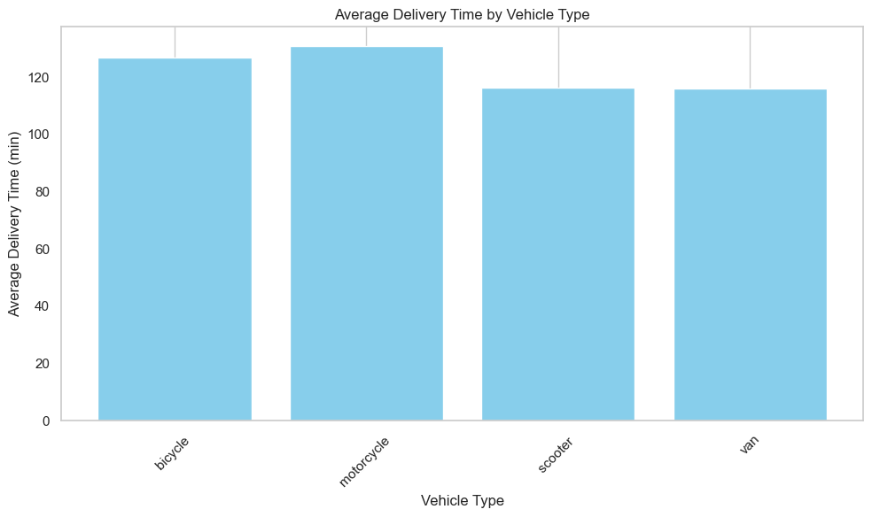

```python
# Group by vehicle type and calculate the average delivery time
vehicle_delivery_time = df.groupby('Vehicle')['Delivery_Time'].mean().reset_index()

# Create bar chart
plt.figure(figsize=(10, 6))
plt.bar(vehicle_delivery_time['Vehicle'], vehicle_delivery_time['Delivery_Time'], color='skyblue')
plt.xlabel('Vehicle Type')
plt.ylabel('Average Delivery Time (min)')
plt.title('Average Delivery Time by Vehicle Type')
plt.xticks(rotation=45)
plt.grid(axis='y')

# Show the plot
plt.tight_layout()
plt.show()
```

## Categorias Entregadas por vehiculo

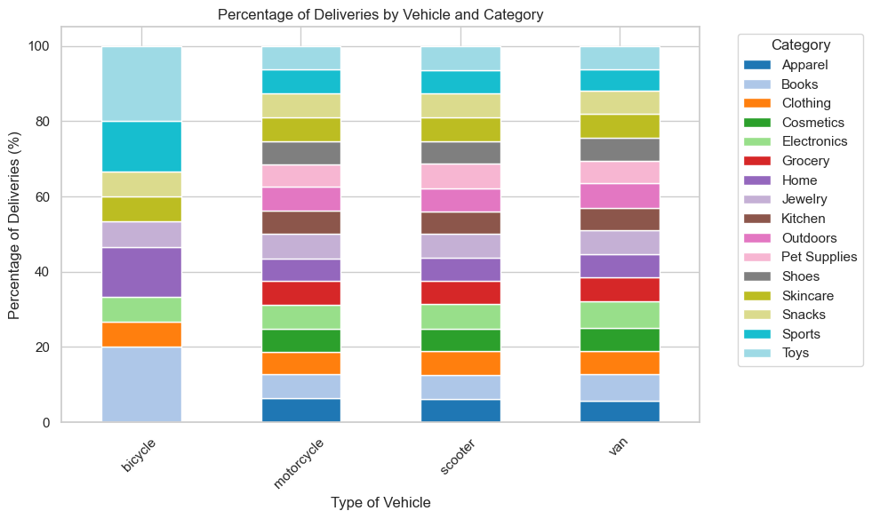

```python
# Group by vehicle and category, and count the number of deliveries
vehicle_category_counts = df.groupby(['Vehicle', 'Category']).size().reset_index(name='Count')

# Calculate the percentage for each vehicle and category
vehicle_category_counts['Percentage'] = vehicle_category_counts.groupby('Vehicle')['Count'].apply(lambda x: (x / x.sum()) * 100).reset_index(drop=True)

# Create a pivot table to facilitate the plot
vehicle_category_pivot = vehicle_category_counts.pivot(index='Vehicle', columns='Category', values='Percentage')

# Plot the stacked bar chart
vehicle_category_pivot.plot(kind='bar', stacked=True, figsize=(10, 6), colormap='tab20')

# Set titles and labels
plt.title('Percentage of Deliveries by Vehicle and Category')
plt.xlabel('Type of Vehicle')
plt.ylabel('Percentage of Deliveries (%)')
plt.legend(title='Category', bbox_to_anchor=(1.05, 1), loc='upper left')
plt.xticks(rotation=45)

# Show the plot
plt.tight_layout()
plt.show()
```

```python
# Filter the dataframe to get categories delivered by bicycles
bike_deliveries = df[df['Vehicle'] == 'Bicycle']['Category'].unique()

# Get all unique categories
all_categories = df['Category'].unique()

# Identify categories not delivered by bicycle
categories_not_by_bike = [category for category in all_categories if category not in bike_deliveries]

# Print each category on a new line
print("Categories not delivered by bicycle:")
for category in categories_not_by_bike:
    print(category)
```

[output not shown]

## Distancia de Entregas por Vehiculo

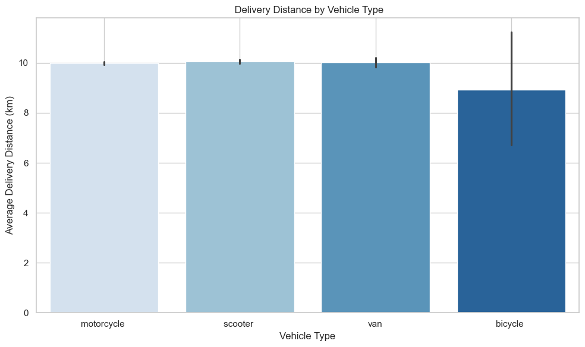

```python
# Create barplot for average delivery distance by vehicle type
plt.figure(figsize=(10, 6))
sns.barplot(x='Vehicle', y='Distance_km', data=df, palette='Blues')

# Set titles and labels
plt.title(' Delivery Distance by Vehicle Type')
plt.xlabel('Vehicle Type')
plt.ylabel('Average Delivery Distance (km)')

plt.grid(True)
plt.tight_layout()
plt.show()
```

## Relacion Edad y Ranking

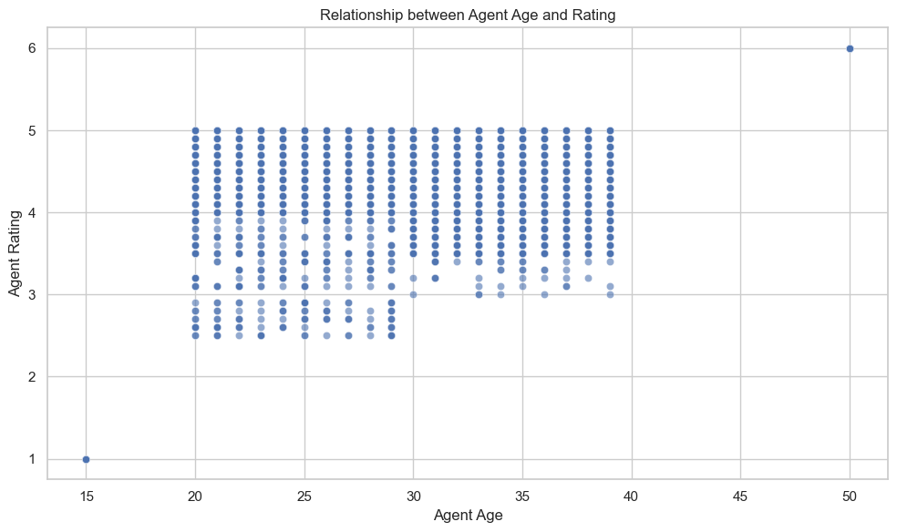

```python
plt.figure(figsize=(10, 6))
sns.scatterplot(x='Agent_Age', y='Agent_Rating', data=df, alpha=0.6)

# Añadir títulos y etiquetas
plt.title('Relationship between Agent Age and Rating')
plt.xlabel('Agent Age')
plt.ylabel('Agent Rating')

# Mostrar el gráfico
plt.tight_layout()
plt.show()
```

Como se puede observar en el grafico anterior existen valores atipicos:

- un agente con 15 años de edad y Rating 1.
- un agente con 50 años de edad y Rating 6.

## Edad del agente y el vehiculo que usa

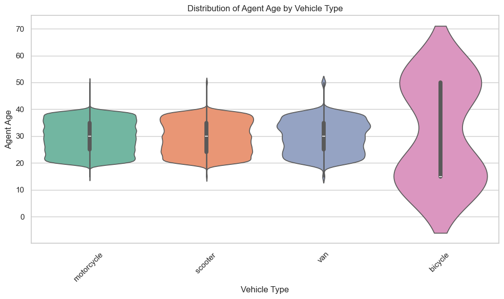

```python
plt.figure(figsize=(10, 6))
sns.violinplot(x='Vehicle', y='Agent_Age', data=df, palette='Set2')

# Añadir títulos y etiquetas
plt.title('Distribution of Agent Age by Vehicle Type')
plt.xlabel('Vehicle Type')
plt.ylabel('Agent Age')

# Rotar las etiquetas de los vehículos si es necesario
plt.xticks(rotation=45)

# Mostrar el gráfico
plt.tight_layout()
plt.show()
```

## Calficacion del agente y el vehiculo que usa

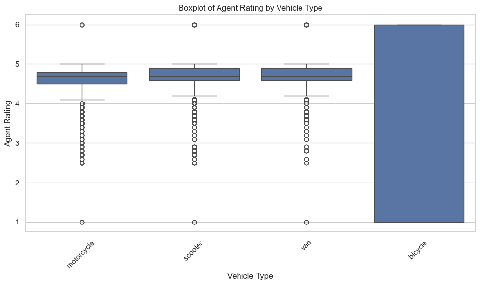

```python
plt.figure(figsize=(10, 6))
sns.boxplot(x='Vehicle', y='Agent_Rating', data=df)
plt.title('Boxplot of Agent Rating by Vehicle Type')
plt.xlabel('Vehicle Type')
plt.ylabel('Agent Rating')
plt.xticks(rotation=45)
plt.tight_layout()
plt.show()
```

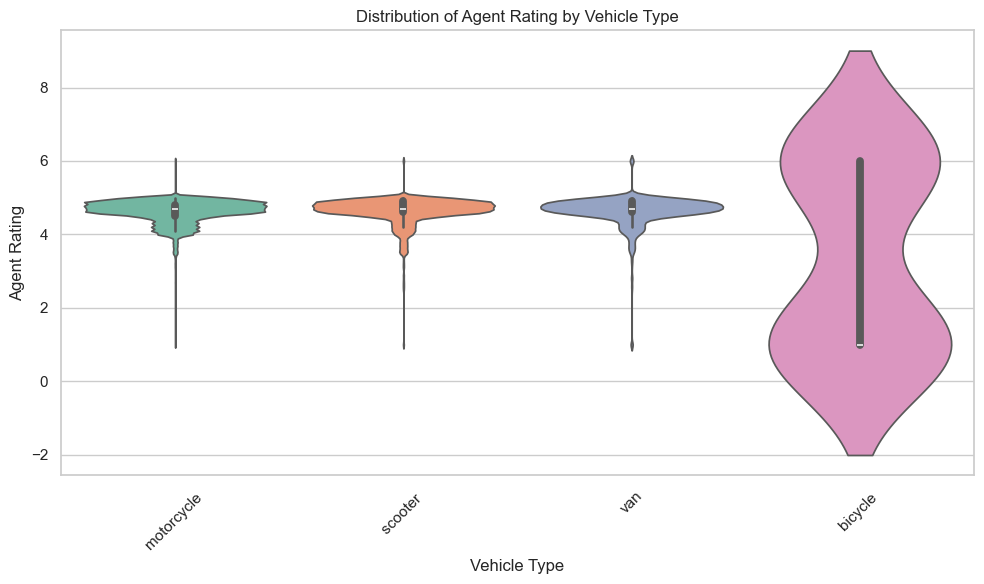

```python
plt.figure(figsize=(10, 6))
sns.violinplot(x='Vehicle', y='Agent_Rating', data=df, palette='Set2')
plt.title('Distribution of Agent Rating by Vehicle Type')
plt.xlabel('Vehicle Type')
plt.ylabel('Agent Rating')
plt.xticks(rotation=45)
plt.tight_layout()
plt.show()
```

## Vehiculos vs Condiciones Climaticas

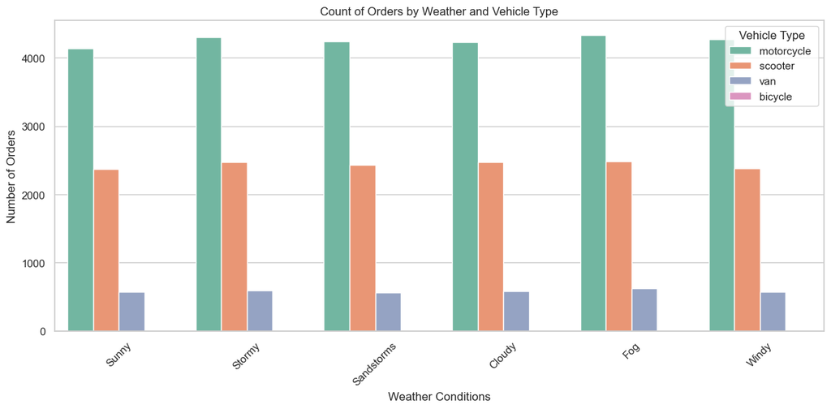

```python
plt.figure(figsize=(12, 6))
sns.countplot(data=df, x='Weather', hue='Vehicle', palette='Set2')

# Añadir títulos y etiquetas
plt.title('Count of Orders by Weather and Vehicle Type')
plt.xlabel('Weather Conditions')
plt.ylabel('Number of Orders')
plt.legend(title='Vehicle Type', loc='upper right')

# Rotar las etiquetas del eje x si es necesario
plt.xticks(rotation=45)

# Mostrar el gráfico
plt.tight_layout()
plt.show()
```

## Vehiculos vs Condiciones de trafico

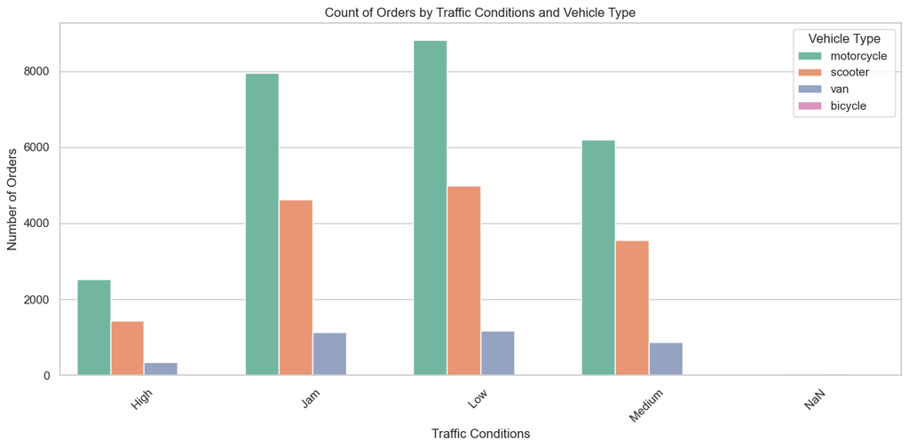

```python
# Crear un gráfico de conteo para visualizar el uso de vehículos por condiciones de tráfico
plt.figure(figsize=(12, 6))
sns.countplot(data=df, x='Traffic', hue='Vehicle', palette='Set2')

# Añadir títulos y etiquetas
plt.title('Count of Orders by Traffic Conditions and Vehicle Type')
plt.xlabel('Traffic Conditions')
plt.ylabel('Number of Orders')
plt.legend(title='Vehicle Type', loc='upper right')

# Rotar las etiquetas del eje x si es necesario
plt.xticks(rotation=45)

# Mostrar el gráfico
plt.tight_layout()
plt.show()
```

```python
# Codificar 'Weather' a valores numéricos
weather_mapping = {
    'Sunny': 1,
    'Cloudy': 2,
    'Stormy': 3,
    'Fog': 4,
    'Windy': 5,
    'Sandstorms': 6
}
data['Weather_Code'] = data['Weather'].map(weather_mapping)

# Comprobar si hay valores faltantes después de la codificación
if data['Weather_Code'].isnull().any():
    print("Existen valores en 'Weather' que no fueron mapeados.")

# Calcular la correlación de Spearman
corr, p_value = spearmanr(data['Weather_Code'], data['Delivery_Time'])

# Mostrar resultados
print(f"Correlación de Spearman entre 'Weather' y 'Delivery_Time': {corr:.2f}")
print(f"Valor p: {p_value:.4f}")

# Interpretación básica
if p_value < 0.05:
    print("La correlación es estadísticamente significativa.")
else:
    print("La correlación no es estadísticamente significativa.")
```

```
Existen valores en 'Weather' que no fueron mapeados.
Correlación de Spearman entre 'Weather' y 'Delivery_Time': nan
Valor p: nan
La correlación no es estadísticamente significativa.
```

## Conclusiones

### Bajo Uso de Bicicletas

- la mayoria de pedidos se realizan con vehículos motorizados, posiblemente por distancia, peso de productos o condiciones climáticas.

### Condiciones Climáticas

- Mal tiempo puede desincentivar el uso de bicicletas, llevando a preferir vehículos motorizados más protegidos.

### Percepción del Cliente y Preferencias

- Los clientes podrían considerar la entrega en bicicleta como más lenta o menos confiable, lo que afecta sus preferencias.

### Impacto en la Sostenibilidad

- El bajo uso de bicicletas limita la sostenibilidad , promover su uso puede mejorar la imagen de la empresa y reducir la huella de carbono.

### Oportunidad de Formación

- Capacitar a ciclistas en planificación de rutas y uso de aplicaciones puede mejorar sus tiempos y eficiencia.

## Recomendaciones

- **Evaluar la Viabilidad de Entregas en Bicicleta**: Analizar rutas y tipos de pedidos que se beneficiarían de entregas en bicicleta.
- **Promocionar Entregas Ecológicas**: Incentivar el uso de bicicletas mediante campañas de sostenibilidad.
- **Mejorar la Logística**: Implementar un sistema que asigne entregas a ciclistas según distancia y condiciones.
- **Recopilar Datos de Satisfacción**: Realizar encuestas para entender la percepción del cliente sobre las entregas en bicicleta.

# Machine Learning

El objetivo de este analsis es lograr implementar un modelo para poder predecir la entrega en menos de 120 minutos , esto sujeto a :

## Preprocesamiento

Vamos a convertir la variable (`Delivery_Time`) a binario :

- Si Delivery_Time < 120, etiquetamos como 1.
- Si Delivery_Time >= 120, etiquetamos como 0.

```python
df['Target'] = (df['Delivery_Time'] < 120).astype(int)
```

### Escalado de las variables:

Dado que **SVM** es sensible a la escala de los datos, vamos a normalizar las características numéricas.

Primero se verifican las columnas del dataframe

```python
# Verificar las columnas del DataFrame
print(df.columns)
```

```
Index(['Order_ID', 'Agent_Age', 'Agent_Rating', 'Store_Latitude',
       'Store_Longitude', 'Drop_Latitude', 'Drop_Longitude', 'Order_Date',
       'Order_Time', 'Pickup_Time', 'Weather', 'Traffic', 'Vehicle', 'Area',
       'Delivery_Time', 'Category', 'Distance_km', 'Target'],
      dtype='object')
```

Asegurarnos que los ratings estén en escala positiva

```python
# Asegurarnos que los ratings estén en escala positiva (0-5)
df['Agent_Rating'] = df['Agent_Rating'].abs()
df['Agent_Rating'] = df['Agent_Rating'].clip(0, 5)
```

Seleccionamos las variables predictoras (features):

```python
X = df[['Agent_Rating'] +
       [col for col in df.columns if col.startswith('Vehicle_')] +
       [col for col in df.columns if col.startswith('Category_')]]
y = df['Target']
```

los valores faltanes se llenan con la media del la columna

```python
X = X.fillna(X.mean())
```

se conservan los indices para luego visualizarlos

```python
indices_originales = X.index
```

Division de datos:

- Dividimos los datos: 80% entrenamiento, 20% prueba

```python
X_train, X_test, y_train, y_test = train_test_split(
    X, y,
    test_size=0.2,
    random_state=42
)
```

Mantenemos la estructura de DataFrame para preservar índice

```python
indices_test = X_test.index
```

Escalamos las características para normalizar su distribución

```python
scaler = StandardScaler()
X_train_scaled = pd.DataFrame(
    scaler.fit_transform(X_train),
    columns=X_train.columns,
    index=X_train.index
)
X_test_scaled = pd.DataFrame(
    scaler.transform(X_test),
    columns=X_test.columns,
    index=X_test.index
)
```

Entrenamiento del modelo

```python
modelo = SVC(kernel='rbf', probability=True, random_state=42)
modelo.fit(X_train_scaled, y_train)
```

```
SVC(probability=True, random_state=42)
```

Evaluacion del modelo

```python
accuracy_train = modelo.score(X_train_scaled, y_train)
accuracy_test = modelo.score(X_test_scaled, y_test)
probabilidades = modelo.predict_proba(X_test_scaled)[:, 1]

print(f"Accuracy en entrenamiento: {accuracy_train:.3f}")
print(f"Accuracy en prueba: {accuracy_test:.3f}")
```

```
Accuracy en entrenamiento: 0.593
Accuracy en prueba: 0.592
```

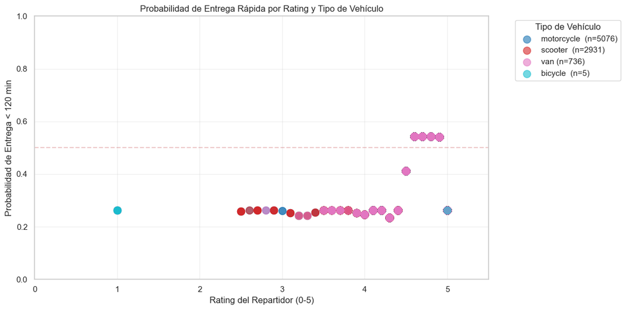

[output not shown]

```python
# Crear el gráfico
plt.figure(figsize=(12, 6))

# Obtener los tipos de vehículo para los datos de prueba
tipos_vehiculo = df.loc[indices_test, 'Vehicle']
tipos_unicos = tipos_vehiculo.unique()

# Crear un mapa de colores
colores = plt.cm.tab10(np.linspace(0, 1, len(tipos_unicos)))

# Graficar cada tipo de vehículo por separado
for tipo, color in zip(tipos_unicos, colores):
    mask = tipos_vehiculo == tipo
    plt.scatter(
        df.loc[indices_test, 'Agent_Rating'][mask],
        probabilidades[mask],
        label=f"{tipo} (n={sum(mask)})",
        alpha=0.6,
        s=100,
        color=color
    )

# Configurar el gráfico
plt.xlabel('Rating del Repartidor (0-5)')
plt.ylabel('Probabilidad de Entrega < 120 min')
plt.title('Probabilidad de Entrega Rápida por Rating y Tipo de Vehículo')
plt.legend(title="Tipo de Vehículo", bbox_to_anchor=(1.05, 1), loc='upper left')
plt.grid(True, alpha=0.3)

# Ajustar los límites
plt.xlim(0, 5.5)
plt.ylim(0, 1)

# Agregar línea de referencia
plt.axhline(y=0.5, color='r', linestyle='--', alpha=0.3, label='Umbral 50%')

# Ajustar el layout
plt.tight_layout()

# Mostrar el gráfico
plt.show()

# Crear DataFrame con resultados
resultados = pd.DataFrame({
    'Rating': df.loc[indices_test, 'Agent_Rating'],
    'Tipo_Vehiculo': df.loc[indices_test, 'Vehicle'],
    'Probabilidad': probabilidades
})

# Estadísticas por tipo de vehículo
estadisticas = pd.DataFrame({
    'Total_Entregas': resultados.groupby('Tipo_Vehiculo').size(),
    'Probabilidad_Media': resultados.groupby('Tipo_Vehiculo')['Probabilidad'].mean(),
    'Rating_Promedio': resultados.groupby('Tipo_Vehiculo')['Rating'].mean(),
    'Desv_Est_Probabilidad': resultados.groupby('Tipo_Vehiculo')['Probabilidad'].std()
}).round(3)

print("\nEstadísticas por tipo de vehículo:")
print(estadisticas)

# Correlación entre Rating y Probabilidad por tipo de vehículo
print("\nCorrelación Rating-Probabilidad por tipo de vehículo:")
for tipo in tipos_unicos:
    datos_tipo = resultados[resultados['Tipo_Vehiculo'] == tipo]
    corr = datos_tipo['Rating'].corr(datos_tipo['Probabilidad'])
    print(f"{tipo}: {corr:.3f}")
```

## usando red neuronal

[output not shown]

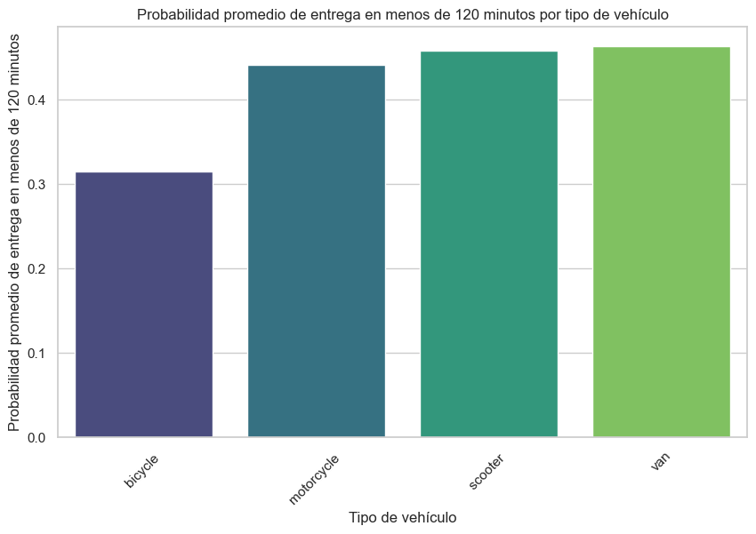

```python
model = Sequential([
    Dense(79, activation='relu', input_shape=(X_train.shape[1],)),  # Capa oculta con 64 neuronas
    Dense(94, activation='relu'),                                  # Capa oculta con 32 neuronas
    Dense(1, activation='sigmoid')                                 # Capa de salida con activación sigmoide para probabilidad
])

# Compilar el modelo
model.compile(optimizer='adam', loss='binary_crossentropy', metrics=['accuracy'])

# Entrenar el modelo
history = model.fit(X_train, y_train, epochs=30, batch_size=39, validation_split=0.2,verbose=1)

# Evaluar el modelo en el conjunto de prueba
test_loss, test_accuracy = model.evaluate(X_test, y_test)
print(f'Test Accuracy: {test_accuracy}')

# Predicción de probabilidades
y_pred_prob = model.predict(X_test)

# Agregar las probabilidades al DataFrame de prueba
X_test_df = pd.DataFrame(X_test, columns=X.columns)  # Convertir X_test en DataFrame para facilitar el análisis
X_test_df['Vehicle'] = df.loc[X_test_df.index, 'Vehicle']  # Agregar la columna de tipo de vehículo
X_test_df['Probability'] = y_pred_prob  # Agregar las probabilidades predichas

# Calcular el promedio de probabilidades por cada tipo de vehículo
probabilities_by_vehicle = X_test_df.groupby('Vehicle')['Probability'].mean()

# Crear una gráfica de barras para mostrar las probabilidades promedio por tipo de vehículo
plt.figure(figsize=(10, 6))
sns.barplot(x=probabilities_by_vehicle.index, y=probabilities_by_vehicle.values, palette="viridis")
plt.title("Probabilidad promedio de entrega en menos de 120 minutos por tipo de vehículo")
plt.xlabel("Tipo de vehículo")
plt.ylabel("Probabilidad promedio de entrega en menos de 120 minutos")
plt.xticks(rotation=45)
plt.show()
```